# Multiple Regression Analysis

Thomas Sun

Friday, October 14, 2016

## Abstract

This report attempts to reproduce the results found in Chapter 3, Section 3.2 of the book **An Introduction to Statistical Learning**. In this section, a multiple regression analysis is run on the *Advertising* dataset, containing data on sales and advertising budget for a particular product. Using a multiple linear regression model and a simple linear regression model for each type of advertising, I find the same estimates of the coefficients, obtain the same quality index results, and similar looking plots as the ones contained in the book.

## Introduction

The goal is to determine whether there is an effect of advertising on sales, ideally to increase product sales. Specifically, if increasing spending on certain mediums of advertising has a relationship with the amount of sales on a product. This section is concerned with three specific mediums of advertising, `TV`, `Radio`, and `Newspaper`. For each medium, it fits three separate simple regression models to `Sales`, and finally a multiple regression model including all three. When comparing the three regressors individually in the simple regression case, the textbook finds that `Radio` has the strongest relationship on `Sales`, followed by `Newspaper` and `TV`. Meanwhile, when the three are fit together in multiple regression, it finds that `Radio` has the strongest relationship with `Sales`, followed by `TV` while `Newspaper` has almost no relationship.

## Data

Data was obtained by downloading the *Advertising* dataset available on the textbook’s website. It contains data of the size of advertising budget for `TV`, `Radio`, and `Newspaper` (in thousands of dollars) for a product in 200 different markets, in addition to the number of sales (in thousands of units) for the product in each market.

In the textbook, the authors’ provide their calculated regression statistics and fit measures for each simple and multiple regression analysis that they perform on the *Advertising* dataset, as well as relevant charts.

## Methodology

In order to find the relationship between `Sales` on `TV`, `Radio`, and `Newspaper`, we assume the relationship between the independent and dependent variables is linear. A simple linear model is used for each predictor.

$Sales = \beta{0} + \beta{1}*Predictor + \epsilon$

In addition, we use a multiple linear model to find the relationship for all three predictors.

$Sales = \beta{0} + \beta{1}*TV + \beta{2}*Radio + \beta{3}*Newspaper + \epsilon$

Where $\beta{0}$ is the intercept, $\beta{1}$, $\beta{2}$, and $\beta{3}$ are the regression coefficients for their associated predictor, and $\epsilon$ is the error term. To find an estimate for these coefficients, we use the ordinary least squares method to fit the model. OLS regression was used to calculate regression coefficients and quality indices (mean squared error, R-squared, F-statistic).

## Results

The estimated coefficients for all three simple regressions were calculated and found on the following tables.

Figure 1: Simple Regression of Sales on TV

|  | Estimate | Std. Error | t value | Pr(>\|t\|) |
| --- | --- | --- | --- | --- |
| (Intercept) | 7.033 | 0.458 | 15.360 | 0.000 |
| TV | 0.048 | 0.003 | 17.668 | 0.000 |

Figure 2: Simple Regression of Sales on Radio

|  | Estimate | Std. Error | t value | Pr(>\|t\|) |
| --- | --- | --- | --- | --- |
| (Intercept) | 9.312 | 0.563 | 16.542 | 0.000 |
| Radio | 0.202 | 0.020 | 9.921 | 0.000 |

Figure 3: Simple Regression of Sales on Newspaper

|  | Estimate | Std. Error | t value | Pr(>\|t\|) |
| --- | --- | --- | --- | --- |
| (Intercept) | 12.351 | 0.621 | 19.876 | 0.000 |
| Newspaper | 0.055 | 0.017 | 3.300 | 0.001 |

The predictors, `TV`, `Radio`, and `Newspaper` all have significant, positive, estimated regression coefficients when regressed individually with `Sales`. The following table shows the estimated coefficients in a multiple regression setting.

Figure 4: Multiple Regression of Sales on TV, Radio, and Newspaper

|  | Estimate | Std. Error | t value | Pr(>\|t\|) |
| --- | --- | --- | --- | --- |
| (Intercept) | 2.939 | 0.312 | 9.422 | 0.000 |
| TV | 0.046 | 0.001 | 32.809 | 0.000 |
| Radio | 0.189 | 0.009 | 21.893 | 0.000 |
| Newspaper | -0.001 | 0.006 | -0.177 | 0.860 |

The multiple regression suggests there is no relationship between `Newspaper` and `Sales` unlike the simple regression. On the other hand, `TV` and `Radio` seem to both be useful in explaining `Sales`. The following correlation matrix and scatterplot matrix illustrate the correlations and relationship between all the variables.

Figure 5: Correlation Matrix

|  | TV | Radio | Newspaper | Sales |
| --- | --- | --- | --- | --- |
| TV | 1.000 | 0.055 | 0.057 | 0.782 |
| Radio | 0.055 | 1.000 | 0.354 | 0.576 |
| Newspaper | 0.057 | 0.354 | 1.000 | 0.228 |
| Sales | 0.782 | 0.576 | 0.228 | 1.000 |

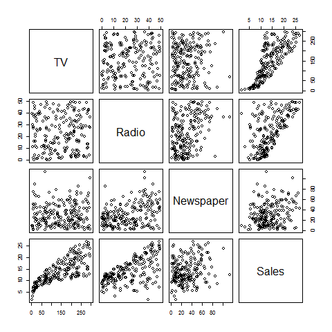

Figure 6: Scatterplot Matrix of TV, Radio, Newspaper, and Sales

The positive correlation between `Newspaper` and `Radio` may explain the notable difference in regression results of `Newspaper`. To assess the quality and fit of the model, the following quantities are calculated.

Figure 7: Quality Indices

|  | Value |
| --- | --- |
| MSE | 1.686 |
| $R^2$ | 0.897 |
| F-Stat | 570.271 |

## Conclusions

Using a simple and multiple linear regression analysis, I successfully managed to reproduce the regression analysis and results found in the textbook. The values for the estimated coefficients and quality indices are equivalent.

The large F-statistic, calculated in Figure 7, suggests that there is at least one predictor useful for predicting the response.

In the simple regressions, it seemed that all three predictors were useful in predicting the reponse. However, from Figure 4, the multiple regression showed that `Newspaper` was no longer significant. This is because multiple regression estimates the coeffcient while holding the other predictors constant. Since there is a notable correlation between `Newspaper` and `Radio`, it suggests that the positive relationship between `Newspaper` and `Sales` could be explained mostly by other predictors. Still, `TV` and `Radio` remain signficant as predictors since both maintain a very small p-value.

To assess model fit, the mean residual error and $R^2$ statistic were calculated in Figure 7. The mean residual error is relatively small while the $R^2$ is close to 1, suggesting the model fits very well with the data.

We assume that the true population regression plane has a linear fit, however this is subject to model bias, which hurts the accuracy of the model. Confidence intervals can be used to determine the accuracy around the average of `Sales`.

The results from the multiple regression analysis suggest that increasing TV and Radio advertising budget means the number of sales for the product will also increase.